# Session2

Natalia Levshina

2026-06-03

## Creating “classic” and interactive D3 graphs of colexifications

You will need two packages: igraph and networkD3. Install them first, then load:

```r
library(igraph)
library(networkD3)
```

The dataset is called foot_graph.txt. It contains top frequent colexified concepts of FOOT.

```r
foot <- read.table("foot_graph.txt", header = T)
```

First, we make a traditional graph using functions from package igraph. We can see the vertices (nodes), the edges (links) and the weights (frequencies of colexifications).

```r
foot_graph <- graph_from_data_frame(foot, directed = FALSE)
V(foot_graph)#get the vertices (nodes)
```

```
## + 7/7 vertices, named, from 2f2891c:
## [1] foot      leg       lower_leg thigh     footprint toe       heel
```

```r
E(foot_graph)#get the edges
```

```
## + 14/14 edges from 2f2891c (vertex names):
##  [1] foot     --leg       foot     --lower_leg foot     --thigh
##  [4] foot     --footprint foot     --toe       foot     --heel
##  [7] leg      --lower_leg leg      --thigh     leg      --toe
## [10] leg      --heel      lower_leg--thigh     lower_leg--toe
## [13] thigh    --toe       footprint--toe
```

```r
E(foot_graph)$weight #get the weights (frequencies)
```

```
##  [1] 1526   61   22   22   15   14   23   62    3    5   59    2    1    1
```

Of course, we can also plot the graph:

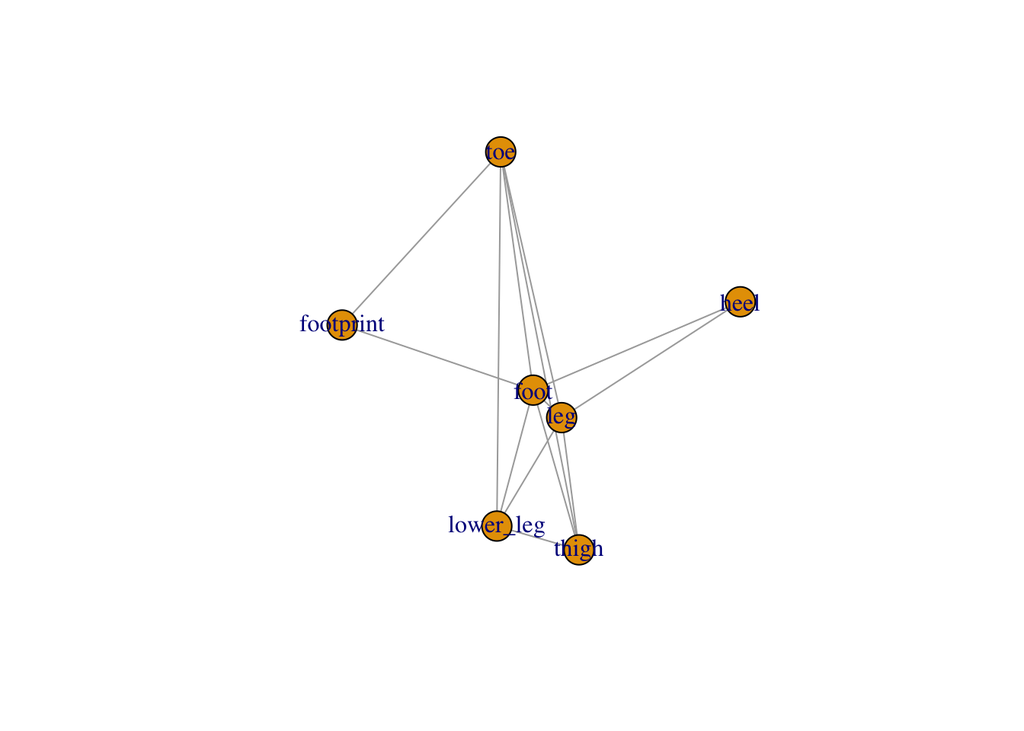

```r
plot(foot_graph)
```

The graph is easily customizable:

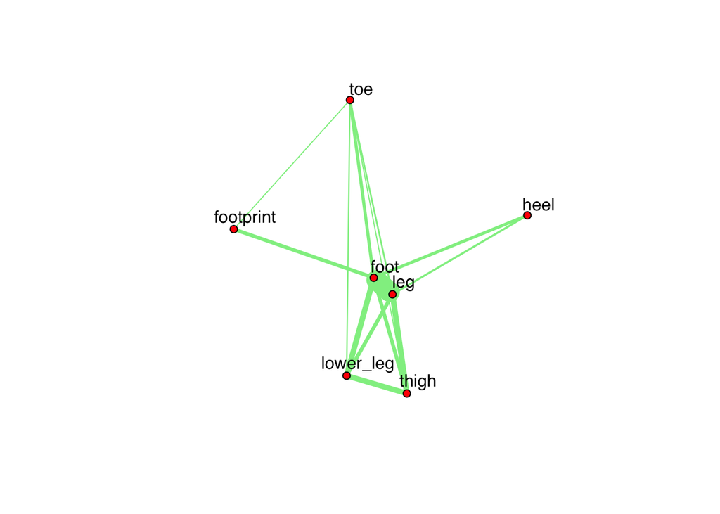

```r
plot(foot_graph, edge.width = E(foot_graph)$weight^0.4, edge.color = "lightgreen", vertex.label.cex = 1, vertex.size = 5, vertex.label.color = "black", vertex.label.family = "sans", vertex.color = "red", vertex.label.dist = 1.5)
```

This is informative, but sometimes it is practical to have an interactive graph. A popular tool is networkD3.

```r
foot_D3 <- igraph_to_networkD3(foot_graph)
forceNetwork(Links = foot_D3$links, Nodes = foot_D3$nodes, NodeID = 'name', Group = 'name', opacity = 0.9, Value = "value", linkDistance = 200, fontSize = 20, linkColour = "lightgreen", opacityNoHover = 0.9)
```

[interactive chart not shown]

## Creating probabilistic maps of causatives

You will need several add-on packages: cluster and smacof for performing the MDS, fields, grDevices and googleVis for different visualizations.

```r
library(cluster)
library(smacof)
library(fields)
library(grDevices)
library(googleVis)
```

The dataset is causatives.txt.

```r
causatives <- read.table("causatives.txt", header = T, sep = "\t", quote = "", stringsAsFactors = T)
str(causatives)
```

```
## 'data.frame':    72 obs. of  20 variables:
##  $ Film: Factor w/ 8 levels "Amelie","Avatar",..: 1 1 1 1 1 1 1 1 1 1 ...
##  $ Text: Factor w/ 72 levels "...and won't let the tree thrive.",..: 15 47 48 50 62 24 5 6 54 7 ...
##  $ FRA : Factor w/ 6 levels "autoriser","faire",..: 2 2 4 NA 2 4 4 4 4 2 ...
##  $ ENG : Factor w/ 6 levels "allow","force",..: 4 NA 5 6 4 5 5 5 NA 6 ...
##  $ GER : Factor w/ 3 levels "bringen","erlauben",..: 3 3 3 3 3 3 3 NA 3 3 ...
##  $ SPA : Factor w/ 5 levels "dejar","forzar",..: NA 3 1 NA NA 1 1 NA 1 3 ...
##  $ DUT : Factor w/ 3 levels "doen","dwingen",..: NA NA 3 1 3 3 3 3 NA 1 ...
##  $ SWE : Factor w/ 3 levels "fa","lata","tvinga": NA NA 2 1 NA 2 2 2 NA NA ...
##  $ ITA : Factor w/ 4 levels "costringere",..: 2 2 2 NA NA 3 3 NA 3 2 ...
##  $ POR : Factor w/ 5 levels "deixar","fazer",..: NA NA NA NA NA 1 1 1 NA 2 ...
##  $ ROM : Factor w/ 5 levels "convinge","face",..: NA 2 NA NA NA NA 3 NA 3 2 ...
##  $ POL : Factor w/ 3 levels "dawac","pozwolic",..: NA NA NA NA NA NA 2 NA NA NA ...
##  $ SLO : Factor w/ 5 levels "dati","dopustiti",..: 1 NA NA NA NA NA 4 NA 4 NA ...
##  $ CZE : Factor w/ 6 levels "dat","dovolit",..: 1 NA 3 NA NA 3 3 NA 3 NA ...
##  $ RUS : Factor w/ 5 levels "davat","pozvoljat",..: NA NA NA NA NA NA 1 NA NA NA ...
##  $ BUL : Factor w/ 7 levels "davam","dopuskam",..: NA NA 5 3 NA NA 5 5 NA 3 ...
##  $ EST : Factor w/ 6 levels "ajama","andma",..: NA 5 3 NA 3 3 3 3 NA 5 ...
##  $ FIN : Factor w/ 5 levels "antaa","paastaa",..: NA NA 1 4 NA NA 1 1 NA NA ...
##  $ HUN : Factor w/ 3 levels "enged","hagy",..: NA NA 2 NA NA 2 2 2 NA NA ...
##  $ NOR : Factor w/ 4 levels "fa","la","tillate",..: NA 2 2 1 1 2 2 2 2 NA ...
```

```r
head(causatives)
```

```
##     Film                                                              Text
## 1 Amelie                                   I had my nasal cavities fixed.
## 2 Amelie        Take two regulars, _mix_ them together and let them stew .
## 3 Amelie        Take two regulars, mix them together and _let_ them stew .
## 4 Amelie The thrill of this rare contact makes her heart beat like a drum.
## 5 Amelie                                When a girl has her photo taken...
## 6 Amelie                                   If you let this chance go by...
##       FRA  ENG    GER   SPA   DUT  SWE      ITA    POR  ROM  POL  SLO    CZE
## 1   faire have lassen  <NA>  <NA> <NA>     fare   <NA> <NA> <NA> dati    dat
## 2   faire <NA> lassen hacer  <NA> <NA>     fare   <NA> face <NA> <NA>   <NA>
## 3 laisser  let lassen dejar laten lata     fare   <NA> <NA> <NA> <NA> nechat
## 4    <NA> make lassen  <NA>  doen   fa     <NA>   <NA> <NA> <NA> <NA>   <NA>
## 5   faire have lassen  <NA> laten <NA>     <NA>   <NA> <NA> <NA> <NA>   <NA>
## 6 laisser  let lassen dejar laten lata lasciare deixar <NA> <NA> <NA> nechat
##    RUS      BUL    EST   FIN  HUN  NOR
## 1 <NA>     <NA>   <NA>  <NA> <NA> <NA>
## 2 <NA>     <NA> panema  <NA> <NA>   la
## 3 <NA> ostavjam laskma antaa hagy   la
## 4 <NA>    karam   <NA> saada <NA>   fa
## 5 <NA>     <NA> laskma  <NA> <NA>   fa
## 6 <NA>     <NA> laskma  <NA> hagy   la
```

The first step is to create a distance matrix using Gower distances. We only need the columns with the translations.

```r
causatives.dist <- daisy(causatives[, 3:20])
summary(causatives.dist)
```

```
## 2556 dissimilarities, summarized :
##    Min. 1st Qu.  Median    Mean 3rd Qu.    Max.    NA's
##  0.0000  0.1429  0.6000  0.5415  0.9091  1.0000       1
## Metric :  mixed ;  Types = N, N, N, N, N, N, N, N, N, N, N, N, N, N, N, N, N, N
## Number of objects : 72
```

```r
causatives.dist[1:3]
```

```
## [1] 0.0 0.6 0.5
```

```r
causatives[c(1, 2),]
```

```
##     Film                                                       Text   FRA  ENG
## 1 Amelie                            I had my nasal cavities fixed.  faire have
## 2 Amelie Take two regulars, _mix_ them together and let them stew . faire <NA>
##      GER   SPA  DUT  SWE  ITA  POR  ROM  POL  SLO  CZE  RUS  BUL    EST  FIN
## 1 lassen  <NA> <NA> <NA> fare <NA> <NA> <NA> dati  dat <NA> <NA>   <NA> <NA>
## 2 lassen hacer <NA> <NA> fare <NA> face <NA> <NA> <NA> <NA> <NA> panema <NA>
##    HUN  NOR
## 1 <NA> <NA>
## 2 <NA>   la
```

```r
causatives[c(1, 3),]
```

```
##     Film                                                       Text     FRA
## 1 Amelie                            I had my nasal cavities fixed.    faire
## 3 Amelie Take two regulars, mix them together and _let_ them stew . laisser
##    ENG    GER   SPA   DUT  SWE  ITA  POR  ROM  POL  SLO    CZE  RUS      BUL
## 1 have lassen  <NA>  <NA> <NA> fare <NA> <NA> <NA> dati    dat <NA>     <NA>
## 3  let lassen dejar laten lata fare <NA> <NA> <NA> <NA> nechat <NA> ostavjam
##      EST   FIN  HUN  NOR
## 1   <NA>  <NA> <NA> <NA>
## 3 laskma antaa hagy   la
```

```r
causatives[c(1, 4),]
```

```
##     Film                                                              Text
## 1 Amelie                                   I had my nasal cavities fixed.
## 4 Amelie The thrill of this rare contact makes her heart beat like a drum.
##     FRA  ENG    GER  SPA  DUT  SWE  ITA  POR  ROM  POL  SLO  CZE  RUS   BUL
## 1 faire have lassen <NA> <NA> <NA> fare <NA> <NA> <NA> dati  dat <NA>  <NA>
## 4  <NA> make lassen <NA> doen   fa <NA> <NA> <NA> <NA> <NA> <NA> <NA> karam
##    EST   FIN  HUN  NOR
## 1 <NA>  <NA> <NA> <NA>
## 4 <NA> saada <NA>   fa
```

Now we can represent these distances in a low-dimensional space using MDS. We will use metric MDS (the default). The default number of dimensions (ndim) is two.

```r
causatives.mds <- mds(causatives.dist)
```

How many dimensions do we need?

```r
causatives.mds$stress
```

```
## [1] 0.166
```

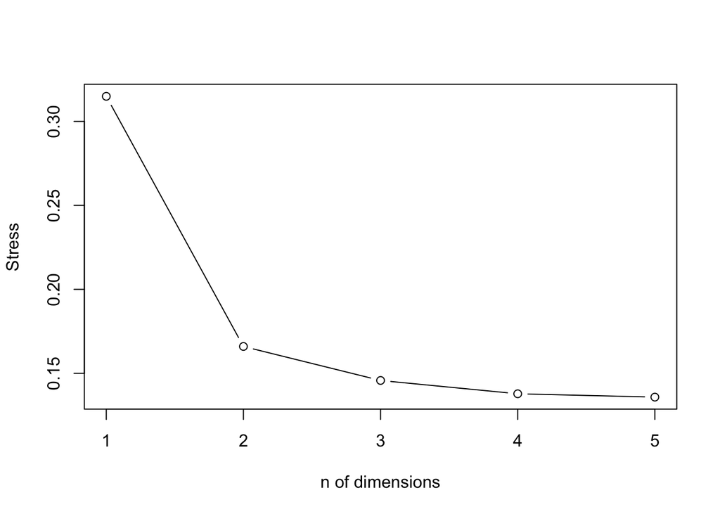

```r
d1 <- mds(causatives.dist, ndim = 1)$stress
d2 <- mds(causatives.dist, ndim = 2)$stress
d3 <- mds(causatives.dist, ndim = 3)$stress
d4 <- mds(causatives.dist, ndim = 4)$stress
d5 <- mds(causatives.dist, ndim = 5)$stress
plot(1:5, c(d1, d2, d3, d4, d5), type = "b", xlab = "n of dimensions", ylab = "Stress")
```

As we can see from the scree plot, there is no significant decrease in stress after two dimensions. So we will use the two-dimensional solution.

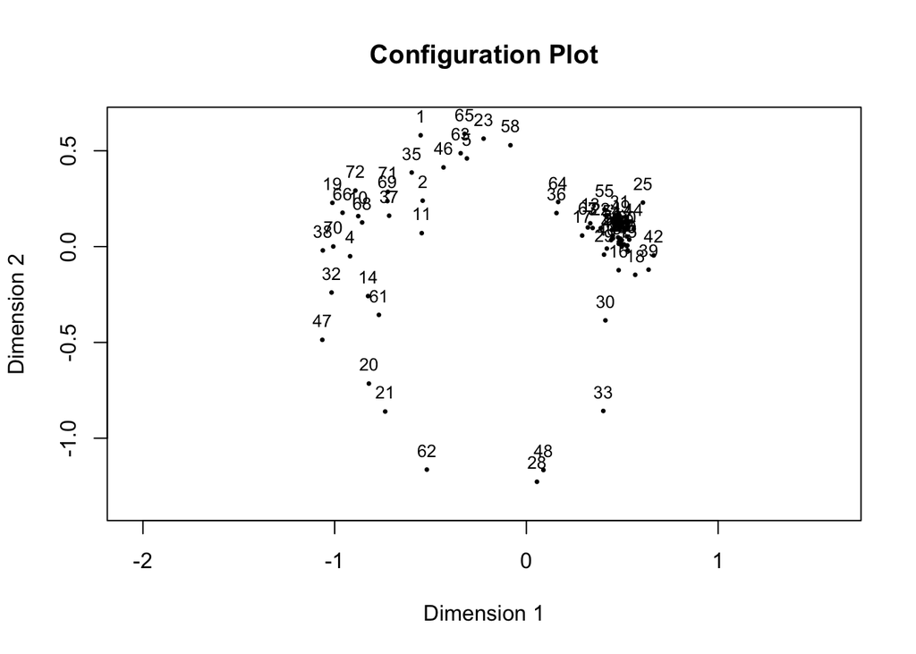

```r
plot(causatives.mds, "conf")
```

But what are these contexts? To interpret them, we can use interactive visualizations in googleVis. The resulting bubble chart will open in your default browser.

```r
text.df <- data.frame(Text = causatives$Text, Dim1 = causatives.mds$conf[, 1], Dim2 = causatives.mds$conf[, 2], ENG = causatives$ENG)
bubbles <- gvisBubbleChart(text.df, idvar = "Text", xvar = "Dim1", yvar = "Dim2", colorvar = "ENG", options = list(sizeAxis = '{maxSize: 10}', vAxis = '{minValue:-0.8, maxValue:0.8}', height = 500, width = 500, bubble="{textStyle:{color: 'none'}}"))
plot(bubbles)
```

```
## starting httpd help server ... done
```

Another common strategy is to plot the language-specific labels in order to compare the form-meaning mappings.

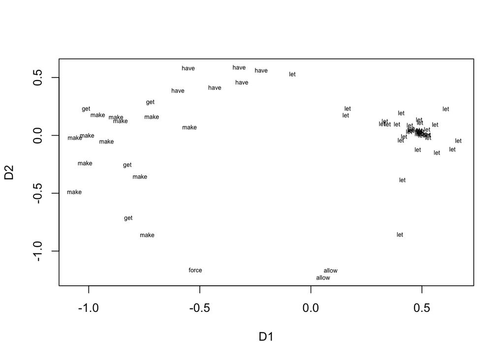

```r
plot(causatives.mds$conf, type = "n")
text(causatives.mds$conf, labels = causatives$ENG, cex = 0.5)
```

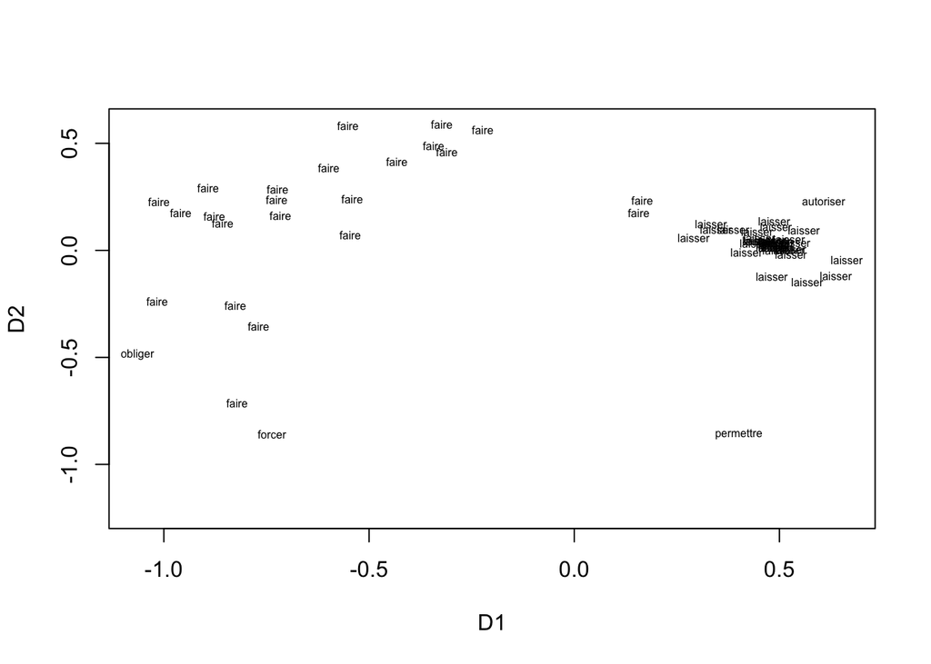

```r
plot(causatives.mds$conf, type = "n")
text(causatives.mds$conf, labels = causatives$FRA, cex = 0.5)
```

Let us now use different colours to represent the Romanian construction with face and the Italian construction with fare. We will add some jitter to avoid overlap.

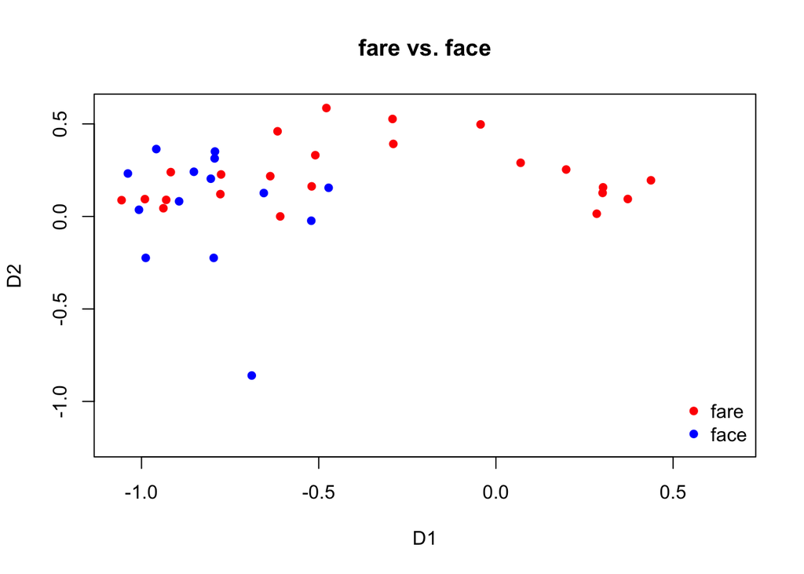

```r
plot(causatives.mds$conf, type = "n", main = "fare vs. face")
points(jitter(causatives.mds$conf[causatives$ROM == "face",], amount = 0.1), col = "blue", pch = 16)
points(jitter(causatives.mds$conf[causatives$ITA == "fare",], amount = 0.1), col = "red", pch = 16)
legend("bottomright", legend = c("fare", "face"), col = c("red", "blue"), pch = 16, bty = "n")
```

Another strategy in situation of overlapping points is to use transparent colours. Below I use the function adjustcolor() from grDevices.

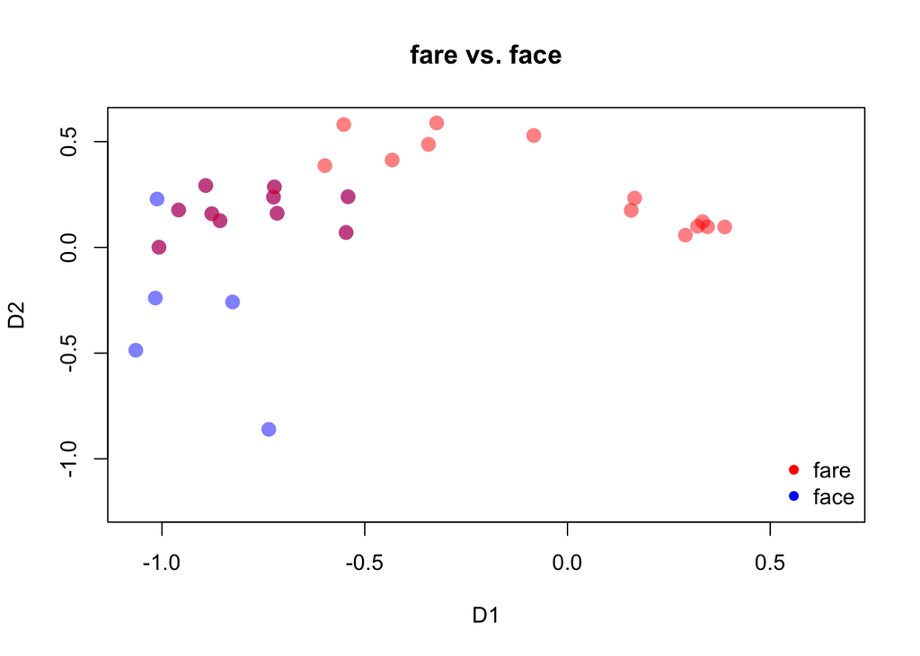

```r
plot(causatives.mds$conf, type = "n", main = "fare vs. face")
points(causatives.mds$conf[causatives$ROM == "face",], col = adjustcolor("blue", alpha.f = 0.5), pch = 16, cex = 1.5)
points(causatives.mds$conf[causatives$ITA == "fare",], col = adjustcolor("red", alpha.f = 0.5), pch = 16, cex = 1.5)
legend("bottomright", legend = c("fare", "face"), col = c("red", "blue"), pch = 16, bty = "n")
```

Sometimes it is useful to create a semantic area instead of isolated dots, with different densities, showing “peaks” with high expected frequency of a construction and “valleys” with less likely semantic areas. We can use a geospatial technique called Kriging to interpolate likely values between the dots. The results can be easily represented as as heat maps, for example. The function Krig() is available in the package fields.

```r
y.ita <- ifelse(causatives$ITA == "fare", 1, 0)
y.fra <- ifelse(causatives$FRA == "faire", 1, 0)
y.spa <- ifelse(causatives$SPA == "hacer", 1, 0)
y.por <- ifelse(causatives$POR == "fazer", 1, 0)
y.rom <- ifelse(causatives$ROM == "face", 1, 0)
```

```r
Krig.rom <- Krig(causatives.mds$conf, y.rom, lambda = 0.05) #try different lambda values
Krig.ita <- Krig(causatives.mds$conf, y.ita, lambda = 0.05)
Krig.fra <- Krig(causatives.mds$conf, y.fra, lambda = 0.05)
Krig.spa <- Krig(causatives.mds$conf, y.spa, lambda = 0.05)
Krig.por <- Krig(causatives.mds$conf, y.por, lambda = 0.05)
```

Now the results can be visualized in a series of maps:

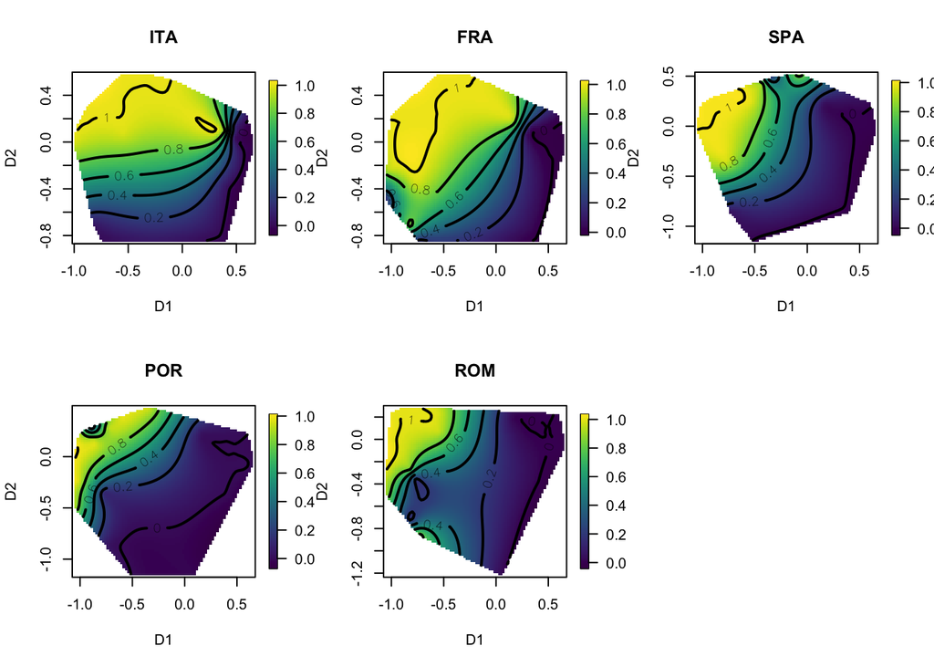

```r
par(mfrow = c(2, 3))
surface(Krig.ita, main = "ITA")
surface(Krig.fra, main = "FRA")
surface(Krig.spa, main = "SPA")
surface(Krig.por, main = "POR")
surface(Krig.rom, main = "ROM")
```